# Tree Methods Lab 2022

Ander Wilson

7/25/2022

## Lab overview

In this lab we conduct an analysis of the NHANES data using two approaches:

- Random forests with covariates regressed out prior to fitting the random forest model.
- BART with covariates included in the tree model.

We will fit the BART model in the lab. This only takes a minute or so. Some of the post-processing for partial dependence plots is slower. We will skip this. These steps were run in advance and output from these steps will be used in the lab.

## Setup

Load the packages used in this lab.

```r
## load required libraries
#install.packages("corrplot")
library(corrplot)
#install.packages("ggplot2")
library(ggplot2)
#install.packages("tidyverse")
library(tidyverse)
#install.packages("BART")
library(BART)
#install.packages("randomForest")
library(randomForest)
```

### Uncomment the below and then load bartmix library when running for first time

This package has some functions to post-process the MCMC from BART models. You can adapt the code in this package to meet other estimation needs with BART.

```r
# install.packages("devtools")
# devtools::install_github("AnderWilson/bartmix")
library(bartmix)
```

## Load and format data

Load in the data and do some data preparation. The packages used here (`randomForests` and `BART`) can handle cateogrical predictors. We therefore do less data preparation because we do not need to make dummy variables.

```r
## read in data and only consider complete data
## this drops 327 individuals
## some tree methods handle missing data but we will not deal with that here
nhanes <- na.omit(read.csv(paste0(here::here(),"/Data/studypop.csv")))
```

```r
## our y variable - ln transformed and scaled mean telomere length
## some tree methods make assumptions about the error variance and some do not
## generally safer to transform the dependent variable to reduce heteroskedasticity
lnLTL_z <- scale(log(nhanes$TELOMEAN))
```

```r
## exposures matrix
## most tree methods are robust to skew and outliers in the predictors
## in this case we long transform and
mixture <- with(nhanes, cbind(LBX074LA, LBX099LA, LBX118LA, LBX138LA, LBX153LA, LBX170LA, LBX180LA, LBX187LA, LBX194LA, LBXHXCLA, LBXPCBLA,
                              LBXD03LA, LBXD05LA, LBXD07LA,
                              LBXF03LA, LBXF04LA, LBXF05LA, LBXF08LA))
# Most tree models are invariant the transformations of the predictors (they don't make a difference)
# here we transform it to make the plots consistent with other methods so they can be compared
mixture   <- apply(mixture, 2, log)
mixture <- scale(mixture)
colnames(mixture) <- c(paste0("PCB",c(74, 99, 118, 138, 153, 170, 180, 187, 194, 169, 126)),
                           paste0("Dioxin",1:3), paste0("Furan",1:4))
exposure_names <- colnames(mixture)
```

```r
## our X matrix
covariates <- with(nhanes, cbind(age_cent, male, bmi_cat3, edu_cat, race_cat,
                                 LBXWBCSI, LBXLYPCT, LBXMOPCT,
                                 LBXNEPCT, LBXEOPCT, LBXBAPCT, ln_lbxcot))
```

## Random Forests

### Regress out covariates

For the random forest analysis we will regress the covariates out prior to fitting the random forest model. This model can be fit by including the covariates in the random forest model instead. The BART analysis provides an example of this.

```r
# regress covariates out
lnLTL_z_residuals <- lm(lnLTL_z~covariates)$residuals
```

### Fit random forest

The key hyperparameters here are the number of trees (`mtree`) and the number of variables used in each tree (`mtry`). These hyperparameters could be selected with cross validation and/or sensitivity analyses can be used.

```r
# fit the random forest model
set.seed(1000)
fit_rf <- randomForest(y=lnLTL_z_residuals,
                       x=mixture,
                       ntree=1000,
                       mtry=6,
                       importance = TRUE)
```

### Prediction

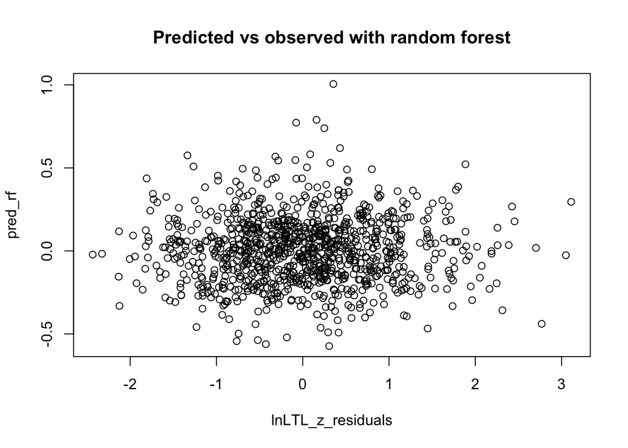

```r
pred_rf <- predict(fit_rf)

# view predicted vs observed
plot(pred_rf~lnLTL_z_residuals,
     main="Predicted vs observed with random forest")
```

### Variable importance

There are many measures of variable importance in trees and none is perfect. Two standard ones for random forests are: - Node Purity: how much splits on a variable improve model fit (reduce MSE for continuous outcomes) - Percent increase in MSE: a permutation approach that is normalized out of bag prediction error In both cases higher is more important.

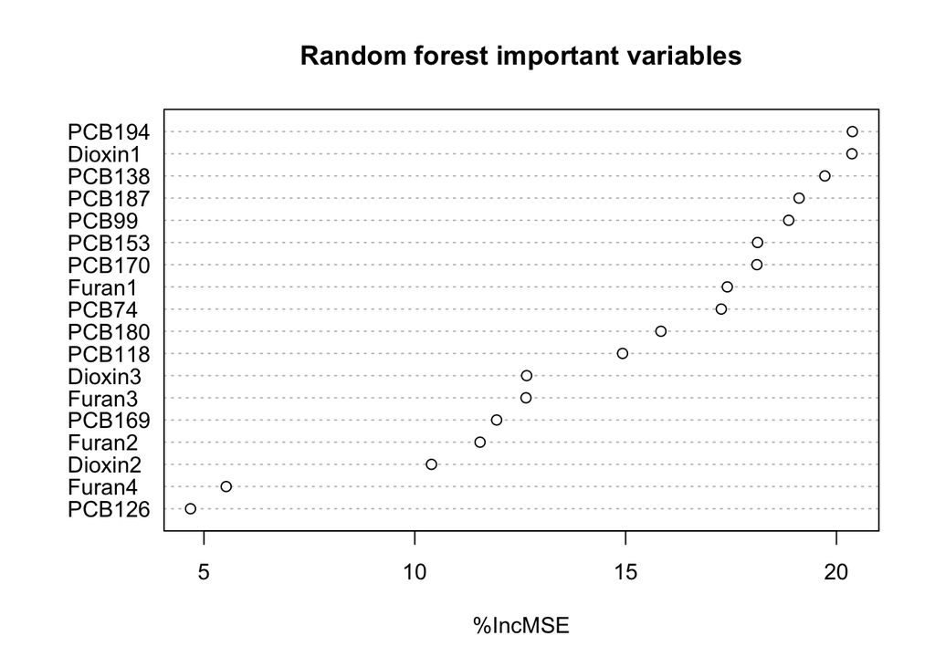

```r
varImpPlot(fit_rf, main = "Random forest important variables", type=1)
```

```r
# extract variable importance from the fit random forest model
rf_var_imortance <- importance(fit_rf)
rf_var_imortance
```

```
##           %IncMSE IncNodePurity
## PCB74   17.266986      36.04026
## PCB99   18.866163      41.19007
## PCB118  14.927281      38.27852
## PCB138  19.723653      38.03660
## PCB153  18.128267      36.68761
## PCB170  18.112456      34.40470
## PCB180  15.836487      32.17797
## PCB187  19.112459      33.20332
## PCB194  20.377478      33.45272
## PCB169  11.940508      40.66846
## PCB126   4.681327      44.70823
## Dioxin1 20.366555      42.87430
## Dioxin2 10.395388      48.40005
## Dioxin3 12.652617      43.89896
## Furan1  17.410977      47.82062
## Furan2  11.547285      39.13725
## Furan3  12.636998      40.72479
## Furan4   5.527158      47.40036
```

### Partial dependence plots

The partial dependence plot shows the main effect of one exposure averaged over values of the other exposures. In this example we are only averaging over the other mixture covariates. We are not allowing for heterogeneity based on covariates because they were regressed out prior to estimating the random forest model. Note that there is no measure of uncertainty (no confidence intervals).

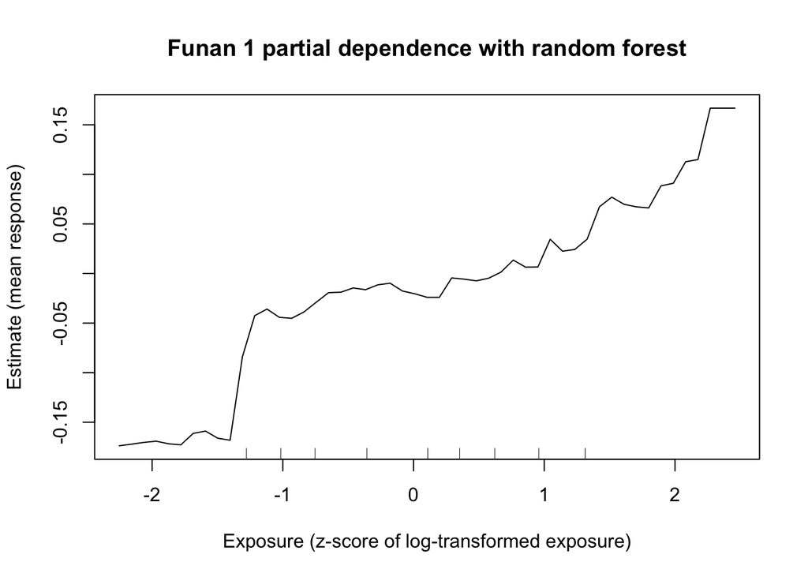

```r
partialPlot(x = fit_rf,
            pred.data = mixture,
            x.var = "Furan1",
            main = "Funan 1 partial dependence with random forest",
            xlab = "Exposure (z-score of log-transformed exposure)",
            ylab = "Estimate (mean response)")
```

## BART

### Fit BART

```r
# fit the BART model
set.seed(1000)
fit_bart <- gbart(x.train=cbind(mixture,covariates),
                  y.train=lnLTL_z,
                  nskip=2000,    # MCMC iterations that are discarded as burning
                  ndpost=2000)   # MCMC iterations after burning that are retained for
```

[output not shown]

```r
load(paste0(here::here(), "/Supervised/Tree Based Methods/bart_fits_for_lab.rda"))
```

### Fitted values

Fitted values in BART are the estiamted mean response at the observed values. Note that this is very different that the random forest plot because the covariates have not been regressed out of the outcome.

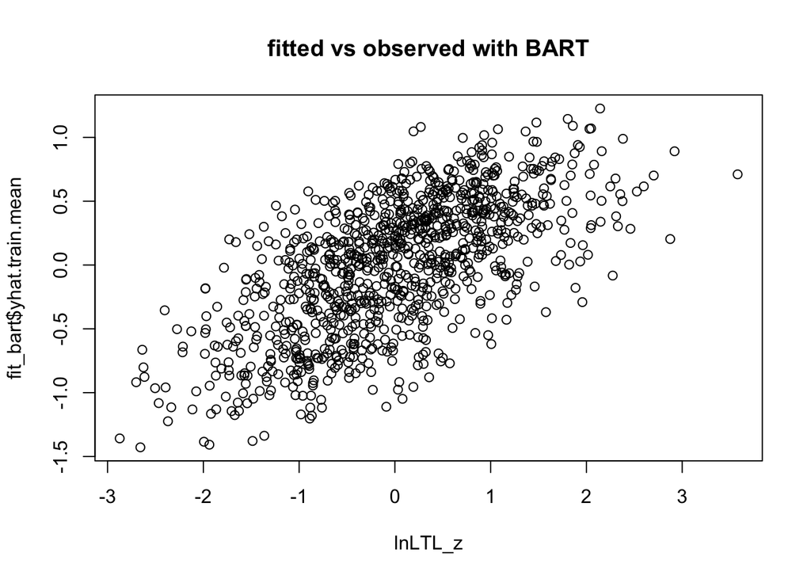

```r
plot(fit_bart$yhat.train.mean~lnLTL_z,
     main="fitted vs observed with BART")
```

### Variable importance

A simple measure of variable importance in BART is how many trees each variable is included in. We get an estimate of this with uncertainty. A variable being included in a lot of trees does not necessarily mean the variable has a large association or an association at all.

BART can be extended to do variable selection (use `sparse=TRUE`). Variable selection will be applied to all predictors including covariates. It may be more appropriate when covariates are regressed out of the outcome. This is likely to lead to more useful measures of variable importance.

The `bartMachines` package has additional variable importance measures.

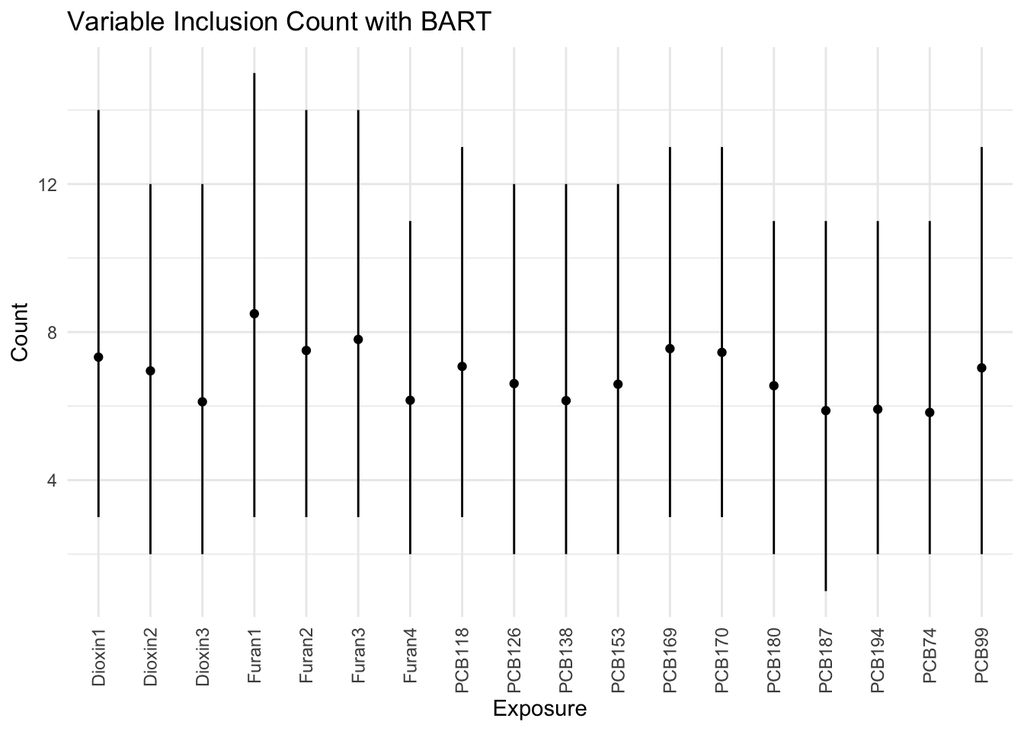

```r
# variable importance for the mixture components with BART
varcount <- data.frame(exposure=exposure_names,
                       mean=fit_bart$varcount.mean[exposure_names],
                       lower=apply(fit_bart$varcount[,exposure_names],2,quantile,0.025),
                       upper=apply(fit_bart$varcount[,exposure_names],2,quantile,0.975))

# visualize the variable importance with BART
ggplot(varcount, aes(x=exposure, y=mean, ymin=lower, ymax=upper)) +
  geom_errorbar(width=0) +
  geom_point() +
  theme_minimal() +
  ggtitle("Variable Inclusion Count with BART") +
  xlab("Exposure") +
  ylab("Count") +
  theme(axis.text.x = element_text(angle = 90, vjust = 0.5, hjust=1))
```

### Partial dependence

The partial dependence functions with BART include uncertainty.

```r
# partial dependence of BART
# funan1_pd <- partialdependence1(fit_bart,
#                                 data=cbind(mixture,covariates),
#                                 exposures = "Furan1",
#                                 L=50)
```

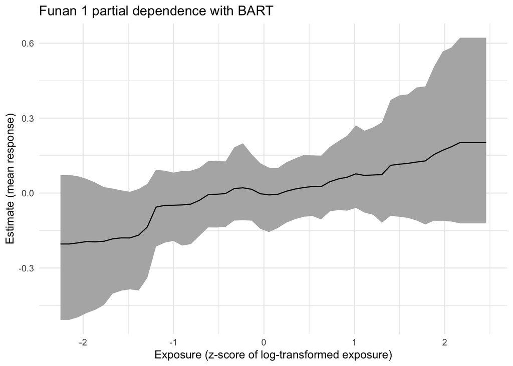

```r
ggplot(funan1_pd, aes(x=x, y=mean, ymin=lower, ymax=upper)) +
  geom_ribbon(fill="grey70") +
  geom_line() +
  theme_minimal() +
  ggtitle("Funan 1 partial dependence with BART") +
  xlab("Exposure (z-score of log-transformed exposure)") +
  ylab("Estimate (mean response)")
```

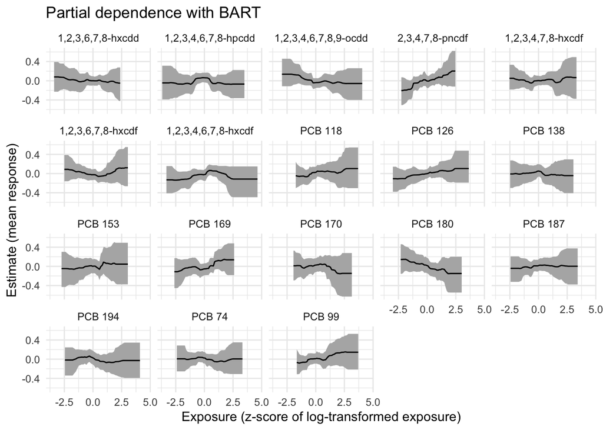

```r
plt <- all_pd %>%
mutate(exposure = fct_recode(exposure, "PCB 74" = "PCB74",
                                "PCB 99" = "PCB99",
                                "PCB 118" = "PCB118",
                                "PCB 138" = "PCB138",
                                "PCB 153" = "PCB153",
                                "PCB 170" = "PCB170",
                                "PCB 180" = "PCB180",
                                "PCB 187" = "PCB187",
                                "PCB 194" = "PCB194",
                                "1,2,3,6,7,8-hxcdd" = "Dioxin1",
                                "1,2,3,4,6,7,8-hpcdd" = "Dioxin2",
                               "1,2,3,4,6,7,8,9-ocdd" =  "Dioxin3",
                               "2,3,4,7,8-pncdf" =  "Furan1",
                               "1,2,3,4,7,8-hxcdf" =  "Furan2",
                               "1,2,3,6,7,8-hxcdf" =  "Furan3",
                               "1,2,3,4,6,7,8-hxcdf" =  "Furan4",
                               "PCB 169" =  "PCB169",
                                "PCB 126" = "PCB126")) %>%
  ggplot(aes(x=x, y=mean, ymin=lower, ymax=upper)) +
  facet_wrap(~exposure) +
  geom_ribbon(fill="grey70") +
  geom_line() +
  theme_minimal() +
  ggtitle("Partial dependence with BART") +
  xlab("Exposure (z-score of log-transformed exposure)") +
  ylab("Estimate (mean response)")
plt
```

### 2-way partial dependence

```r
# pd_2way <- partialdependence2(fit_bart,
#                                 data=cbind(mixture,covariates),
#                                 var = "PCB169",
#                               var2 = "Furan1",
#                               qtls = c(0.1,0.25,0.5,0.75,0.9),
#                                 L=20)
```

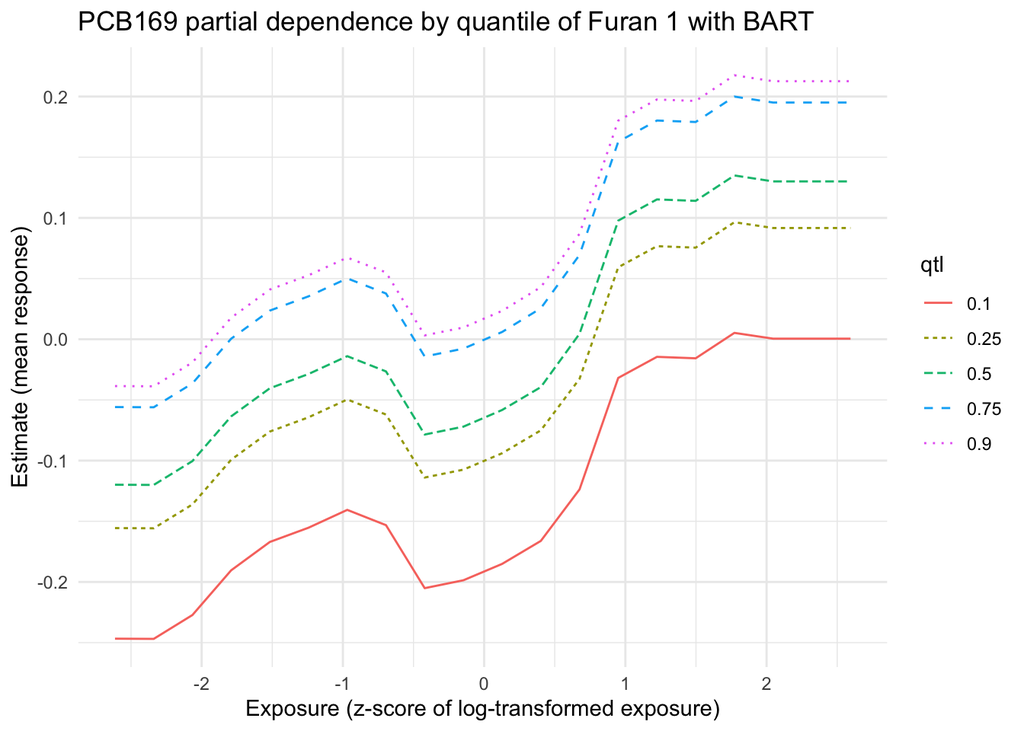

```r
pd_2way$qtl <- as.factor(pd_2way$qtl)
ggplot(pd_2way, aes(x=x, y=mean,
                    color=qtl,
                    linetype=qtl)) +
  geom_line() +
  theme_minimal() +
  ggtitle("PCB169 partial dependence by quantile of Furan 1 with BART") +
  xlab("Exposure (z-score of log-transformed exposure)") +
  ylab("Estimate (mean response)")
```

### Total mixture effect

```r
# totalmix <- totalmixtureeffect(fit_bart,
#                                data=cbind(mixture,covariates),
#                                exposures = exposure_names,
#                                qtls = seq(0.2,0.8,0.05))
```

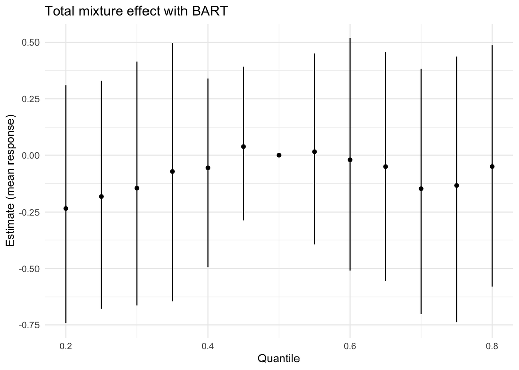

```r
ggplot(totalmix, aes(x=quantile, y=mean, ymin=lower, ymax=upper)) +
  geom_errorbar(width=0) + geom_point() + theme_minimal() +
  ggtitle("Total mixture effect with BART") +
  xlab("Quantile") +
  ylab("Estimate (mean response)")
```